# Aula 06

Leandro Carísio Fernandes

31/03/2022

## Curva Normal Padrão

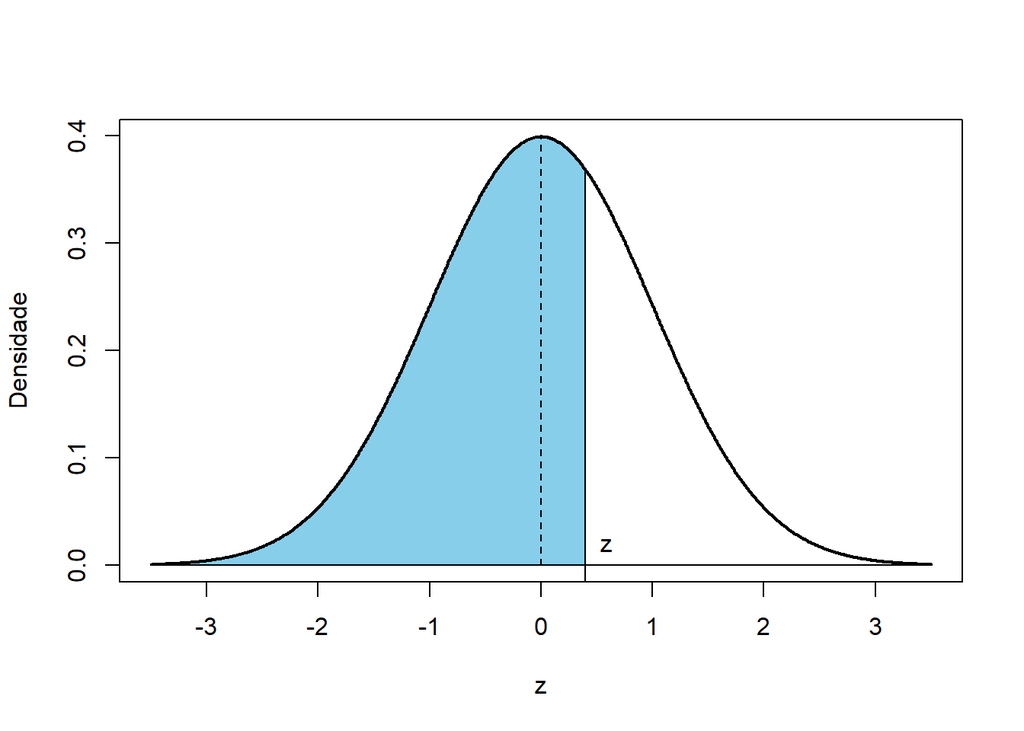

Curva Normal Padrao - Tabela de Probabilidades P(Z <= z)

| z | 0 | 0.01 | 0.02 | 0.03 | 0.04 | 0.05 | 0.06 | 0.07 | 0.08 | 0.09 |
| --- | --- | --- | --- | --- | --- | --- | --- | --- | --- | --- |
| 0.0 | 0.5000 | 0.5040 | 0.5080 | 0.5120 | 0.5160 | 0.5199 | 0.5239 | 0.5279 | 0.5319 | 0.5359 |
| 0.1 | 0.5398 | 0.5438 | 0.5478 | 0.5517 | 0.5557 | 0.5596 | 0.5636 | 0.5675 | 0.5714 | 0.5753 |
| 0.2 | 0.5793 | 0.5832 | 0.5871 | 0.5910 | 0.5948 | 0.5987 | 0.6026 | 0.6064 | 0.6103 | 0.6141 |
| 0.3 | 0.6179 | 0.6217 | 0.6255 | 0.6293 | 0.6331 | 0.6368 | 0.6406 | 0.6443 | 0.6480 | 0.6517 |
| 0.4 | 0.6554 | 0.6591 | 0.6628 | 0.6664 | 0.6700 | 0.6736 | 0.6772 | 0.6808 | 0.6844 | 0.6879 |
| 0.5 | 0.6915 | 0.6950 | 0.6985 | 0.7019 | 0.7054 | 0.7088 | 0.7123 | 0.7157 | 0.7190 | 0.7224 |
| 0.6 | 0.7257 | 0.7291 | 0.7324 | 0.7357 | 0.7389 | 0.7422 | 0.7454 | 0.7486 | 0.7517 | 0.7549 |
| 0.7 | 0.7580 | 0.7611 | 0.7642 | 0.7673 | 0.7704 | 0.7734 | 0.7764 | 0.7794 | 0.7823 | 0.7852 |
| 0.8 | 0.7881 | 0.7910 | 0.7939 | 0.7967 | 0.7995 | 0.8023 | 0.8051 | 0.8078 | 0.8106 | 0.8133 |
| 0.9 | 0.8159 | 0.8186 | 0.8212 | 0.8238 | 0.8264 | 0.8289 | 0.8315 | 0.8340 | 0.8365 | 0.8389 |
| 1.0 | 0.8413 | 0.8438 | 0.8461 | 0.8485 | 0.8508 | 0.8531 | 0.8554 | 0.8577 | 0.8599 | 0.8621 |
| 1.1 | 0.8643 | 0.8665 | 0.8686 | 0.8708 | 0.8729 | 0.8749 | 0.8770 | 0.8790 | 0.8810 | 0.8830 |
| 1.2 | 0.8849 | 0.8869 | 0.8888 | 0.8907 | 0.8925 | 0.8944 | 0.8962 | 0.8980 | 0.8997 | 0.9015 |
| 1.3 | 0.9032 | 0.9049 | 0.9066 | 0.9082 | 0.9099 | 0.9115 | 0.9131 | 0.9147 | 0.9162 | 0.9177 |
| 1.4 | 0.9192 | 0.9207 | 0.9222 | 0.9236 | 0.9251 | 0.9265 | 0.9279 | 0.9292 | 0.9306 | 0.9319 |
| 1.5 | 0.9332 | 0.9345 | 0.9357 | 0.9370 | 0.9382 | 0.9394 | 0.9406 | 0.9418 | 0.9429 | 0.9441 |
| 1.6 | 0.9452 | 0.9463 | 0.9474 | 0.9484 | 0.9495 | 0.9505 | 0.9515 | 0.9525 | 0.9535 | 0.9545 |
| 1.7 | 0.9554 | 0.9564 | 0.9573 | 0.9582 | 0.9591 | 0.9599 | 0.9608 | 0.9616 | 0.9625 | 0.9633 |
| 1.8 | 0.9641 | 0.9649 | 0.9656 | 0.9664 | 0.9671 | 0.9678 | 0.9686 | 0.9693 | 0.9699 | 0.9706 |
| 1.9 | 0.9713 | 0.9719 | 0.9726 | 0.9732 | 0.9738 | 0.9744 | 0.9750 | 0.9756 | 0.9761 | 0.9767 |
| 2.0 | 0.9772 | 0.9778 | 0.9783 | 0.9788 | 0.9793 | 0.9798 | 0.9803 | 0.9808 | 0.9812 | 0.9817 |
| 2.1 | 0.9821 | 0.9826 | 0.9830 | 0.9834 | 0.9838 | 0.9842 | 0.9846 | 0.9850 | 0.9854 | 0.9857 |
| 2.2 | 0.9861 | 0.9864 | 0.9868 | 0.9871 | 0.9875 | 0.9878 | 0.9881 | 0.9884 | 0.9887 | 0.9890 |
| 2.3 | 0.9893 | 0.9896 | 0.9898 | 0.9901 | 0.9904 | 0.9906 | 0.9909 | 0.9911 | 0.9913 | 0.9916 |
| 2.4 | 0.9918 | 0.9920 | 0.9922 | 0.9925 | 0.9927 | 0.9929 | 0.9931 | 0.9932 | 0.9934 | 0.9936 |
| 2.5 | 0.9938 | 0.9940 | 0.9941 | 0.9943 | 0.9945 | 0.9946 | 0.9948 | 0.9949 | 0.9951 | 0.9952 |
| 2.6 | 0.9953 | 0.9955 | 0.9956 | 0.9957 | 0.9959 | 0.9960 | 0.9961 | 0.9962 | 0.9963 | 0.9964 |
| 2.7 | 0.9965 | 0.9966 | 0.9967 | 0.9968 | 0.9969 | 0.9970 | 0.9971 | 0.9972 | 0.9973 | 0.9974 |
| 2.8 | 0.9974 | 0.9975 | 0.9976 | 0.9977 | 0.9977 | 0.9978 | 0.9979 | 0.9979 | 0.9980 | 0.9981 |
| 2.9 | 0.9981 | 0.9982 | 0.9982 | 0.9983 | 0.9984 | 0.9984 | 0.9985 | 0.9985 | 0.9986 | 0.9986 |
| 3.0 | 0.9987 | 0.9987 | 0.9987 | 0.9988 | 0.9988 | 0.9989 | 0.9989 | 0.9989 | 0.9990 | 0.9990 |

## Questões

### 1) Suponha que *X* é normal com média igual a **8** e desvio-padrão igual a **5**. Encontre **P(*X* <= 8,6)**.

```
## [1] "Valor de z = (8.6-8)/5 = 0.120000"
```

```
## [1] "Para z = 0.12 a tabela fornece 0.5478"
```

```
## [1] "Cálculo usando a função pnorm: 0.547758"
```

### 2) Suponha que *X* é normal com média igual a **10** e desvio-padrão igual a **3**. Encontre **P(*X* > 8,6)**.

```
## [1] "Valor de z = (8.6-10)/3 = -0.466667"
```

```
## [1] "Não temos valor da tabela para números negativos. Mas como é simétrica, a P(X <= -a) = P(x > a) para a positivo."
```

```
## [1] "Para z = 0.4666 a tabela fornece próximo a 0.6808"
```

```
## [1] "Cálculo usando a função pnorm: 0.679631"
```

### 3) Suponha que *X* é normal com média igual a **10** e desvio-padrão igual a **6**. Encontre **P(7,3 < *X* <= 12,4)**.

```
## [1] "Para esse exercício podemos normalizar em dois pontos, z1 = (7.3 - 10)/6 e z2 = (12.4 - 10)/6"
```

```
## [1] "z1 = -0.450000, z2 = 0.400000"
```

```
## [1] "Para z = -0.45 a tabela fornece 1 - 0.6736 = 0.326400"
```

```
## [1] "Para z = 0.4 a tabela fornece 0.6554"
```

```
## [1] "A resposta é a subtração das duas coisas: 0.329000"
```

```
## [1] "Cálculo usando a função pnorm: 0.329067"
```

### 4) Suponha que *X* é normal com média igual a **0** e desvio-padrão igual a **1**. Encontre **P(-1,96 < *X* <= 1,96)**.

Na tabela o valor de 1.96 corresponde a 0.9750. Isso significa que a área a direita de 1.96 e a esquerda de -1.96 é de (1 - 0.9750) = 0.025’).

Dessa forma, a valor entre -1.96 e +1.96 é 0.95.

```
## [1] "Cálculo usando a função pnorm: 0.950004"
```

### 5) Suponha que *X* é normal com média igual a **44.90** e desvio-padrão igual a **10.98**. Encontre **P(20 < *X* <= 40)**.

```
## [1] "Convertendo 20 e 40 para o score padrão, temos -2.267760 e -0.446266"
```

```
## [1] "A tabela não tem número negativo, mas pela simetria a área entre -2.2677 e 0.4462 é igual a área entre 0.4462 e 2.2677"
```

```
## [1] "Pela tabela: 0.988400 - 0.673600 = 0.314800"
```

```
## [1] "Cálculo usando a função pnorm: 0.316031"
```

### 6) Suponha que *X* é normal com média igual a **44.90** e desvio-padrão igual a **10.98**. Encontre **P(*X* > 60)**.

```
## [1] "Convertendo 60 para o equivalente na normal padrão: 1.375228"
```

```
## [1] "O valor para esse z na tabela equivale a 0.9147"
```

```
## [1] "Como estamos interessados no lado direito da curva, temos que calcular 1 - 0.9147 = 0.085300"
```

```
## [1] "Cálculo usando a função pnorm: 0.084530"
```

### 7) Repita as questões 5 e 6 tomando por base o histograma a seguir:

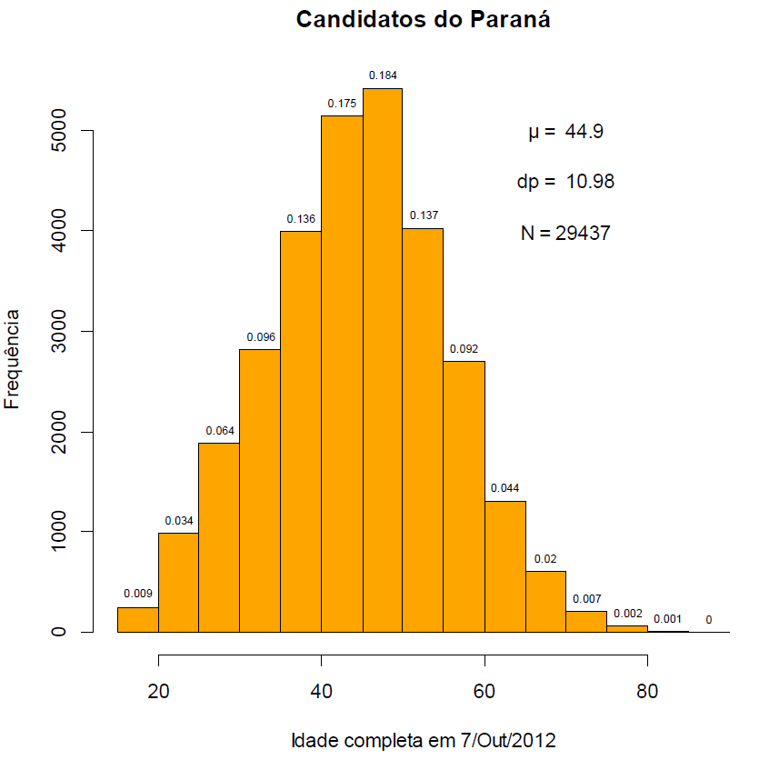

```
## [1] "Idade entre 20 e 40: 0.330000"
```

```
## [1] "Idade acima de 60: 0.074000"
```

### 8) O que pode ser dito sobre os resultados encontrados nas questões 5, 6 e 7?

Embora os resultados das questões 5 e 6 não sejam iguais a da questão 7, eles são semelhantes. Para esse conjunto de dados, nesse intervalo, a distribuição pode ser aproximada por uma distribuição normal com média 44,9 e desvio padrão 10,98.

### 9) Suponha que *X* é normal com média igual a **500** e desvio-padrão igual a **40**. Encontre o valor aproximado de **P(*X* > 550)**.

```
## [1] "Convertendo 550 para o equivalente na normal padrão: 1.250000"
```

```
## [1] "O valor para esse z na tabela equivale a 0.8944"
```

```
## [1] "Como estamos interessados no lado direito da curva, temos que calcular 1 - 0.8944 = 0.105600"
```

```
## [1] "Cálculo usando a função pnorm: 0.105650"
```

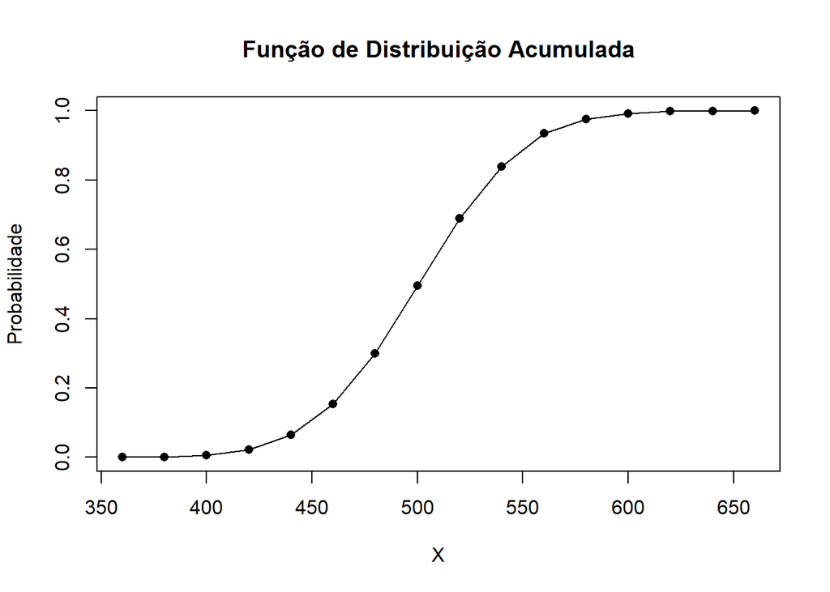

### 10) Usando a Função de Distribuição Acumulada da questão anterior encontre o valor aporximado de **P(450 < *X* <= 550)**.

Dessa forma, P(450 < X <= 550) = 1 - 2*0.1056 = 0.788

```
## [1] "Cálculo usando a função pnorm: 0.788700"
```